# Subasta

Agustin Riquelme y Heriberto Espino

2023-08-30

### 1. Lectura de la base de datos

Podemos observar que la base contiene tres columnas, una de nombre edad, otra número de postores y el último precio de subasta

```
## [1] "Edad"              "Num Postores"      "Precio de subasta"
```

```
## # A tibble: 6 × 3
##    Edad `Num Postores` `Precio de subasta`
##   <dbl>          <dbl>               <dbl>
## 1   127             13                1235
## 2   115             12                1080
## 3   127              7                 845
## 4   150              9                1522
## 5   156              6                1047
## 6   182             11                1979
```

Para la creación de los modelos vamos a definir nuestra variable de respuesta que será el precio de subasta, mientras que las otras dos serán la edad y el número de postores, a cada una de estas variables predictoras se le realizará un modelo de regresión por separado, a continuación lo veremos:

```r
x1 <- data$Edad # Predictora 1
x2 <- data$`Num Postores` # Predicora 2
y <- data$`Precio de subasta` # Variable de respuesta
n <- length(x1) # Número de datos en cada variable
```

Vamos a ver el diagrama de pares para irnos dando una idea de como son los datos de la muestra de la subasta

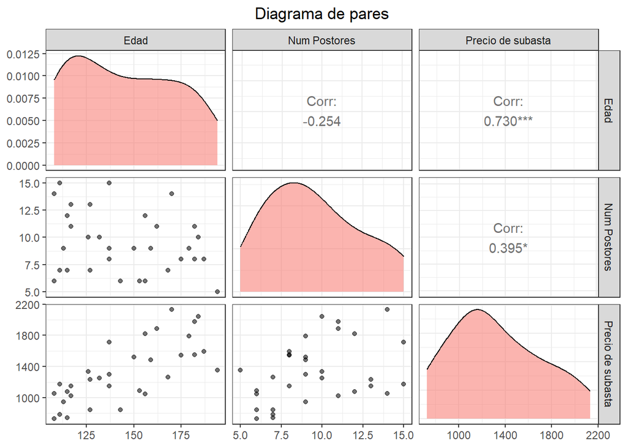

```r
ddp(data)
```

### 2. Modelo 1 Precio~edad

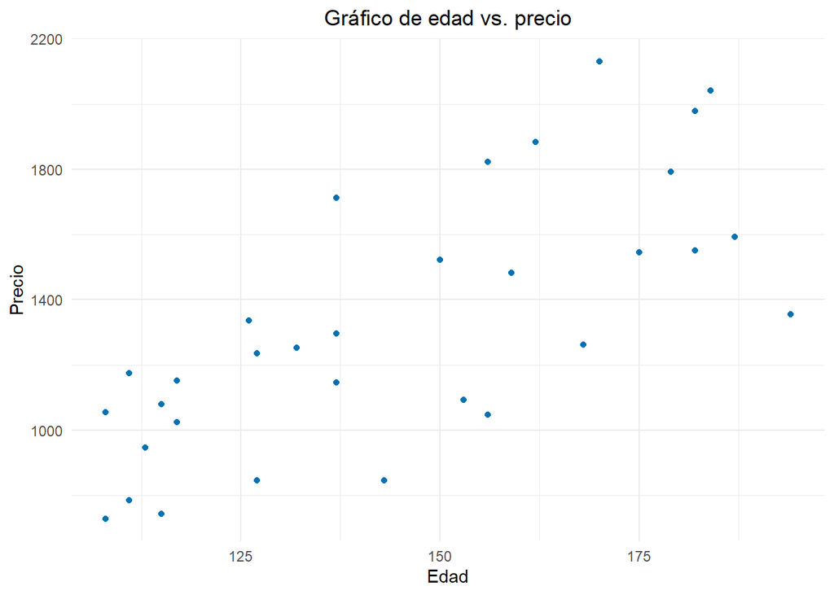

```r
graf.d.x1(x1, x2, y, 0.05)
```

Para ver el comportamiento de los datos, una gráfica de dispersión siempre es la mejor opción, observando dicha herramienta, podemos observar que el comportamiento entre las variables tienen una relación positiva, además de poder observar los límites de los datos que van de 100 a 200 para el caso de la edad, y para el caso del precio desde 600 hasta 2200.

```
##
## Call:
## lm(formula = y ~ x1)
##
## Residuals:
##     Min      1Q  Median      3Q     Max
## -485.04 -192.36   31.03  157.50  541.47
##
## Coefficients:
##             Estimate Std. Error t value Pr(>|t|)
## (Intercept) -192.047    264.372  -0.726    0.473
## x1            10.480      1.793   5.844 2.16e-06 ***
## ---
## Signif. codes:  0 '***' 0.001 '**' 0.01 '*' 0.05 '.' 0.1 ' ' 1
##
## Residual standard error: 273.5 on 30 degrees of freedom
## Multiple R-squared:  0.5324, Adjusted R-squared:  0.5168
## F-statistic: 34.15 on 1 and 30 DF,  p-value: 2.158e-06
```

```r
AIC(modelo1)
```

```
## [1] 453.8772
```

Por otro lado el criterio de Información de Akaike nos va a servir para comparar ambos modelos, es decir, el que tenga menor valor AIC, será el mejor modelo. A continuación se muestra la línea de regresión del modelo.

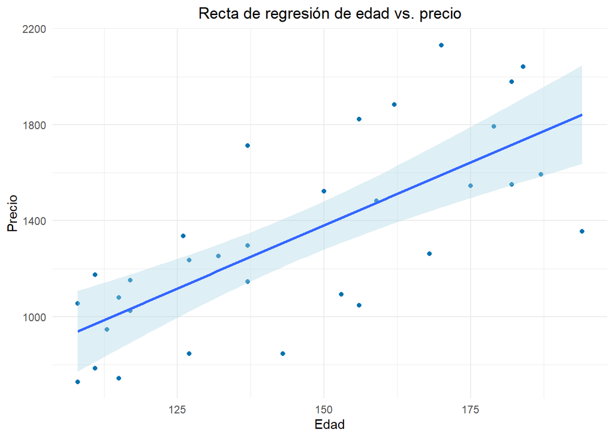

```r
graf.mrls.x1(x1, x2, y, 0.05)
```

### 3. Modelo 2: Precio~Num Postores

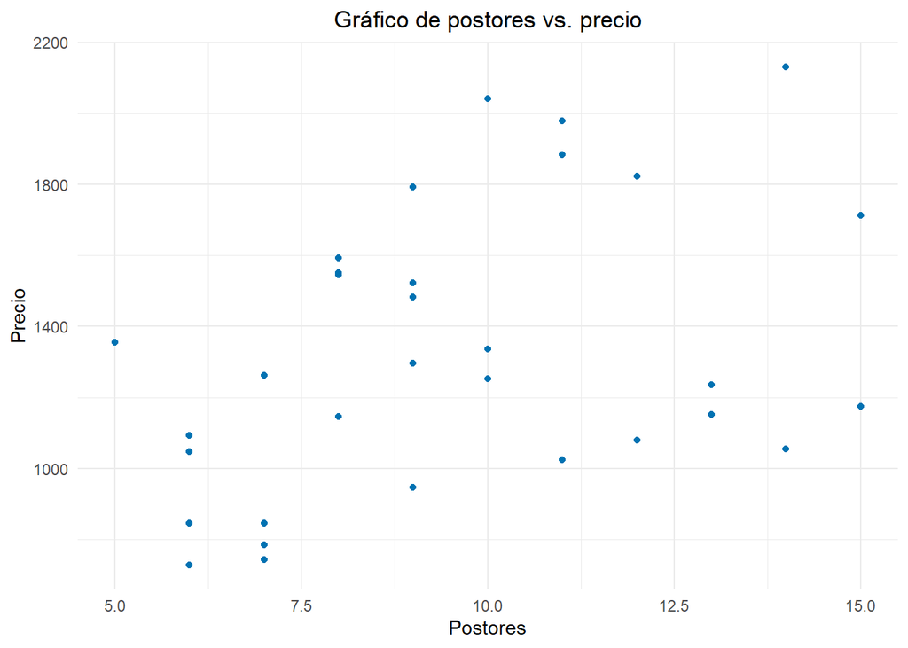

```r
graf.d.x2(x1, x2, y, 0.05)
```

Como mencionamos anteriormente, la gráfica de dispersión es de ayuda para poder observar el comportamiento de nuestras variables, en este caso podemos observar un comportamiento más disperso que el antrior el cual ronda entre los 5 a 15 postores, observando una relación positiva

```
##
## Call:
## lm(formula = y ~ x2)
##
## Residuals:
##     Min      1Q  Median      3Q     Max
## -516.60 -355.05  -29.02  303.23  688.45
##
## Coefficients:
##             Estimate Std. Error t value Pr(>|t|)
## (Intercept)   804.91     230.83   3.487  0.00153 **
## x2             54.76      23.24   2.356  0.02518 *
## ---
## Signif. codes:  0 '***' 0.001 '**' 0.01 '*' 0.05 '.' 0.1 ' ' 1
##
## Residual standard error: 367.4 on 30 degrees of freedom
## Multiple R-squared:  0.1562, Adjusted R-squared:  0.1281
## F-statistic: 5.553 on 1 and 30 DF,  p-value: 0.02518
```

```r
AIC(modelo2)
```

```
## [1] 472.7648
```

Comparando el AIC de ambos modelos, se puede decir que el primero es mejor que este segundo modelo. A continuación se observa la gráfica de dispersión para este modelo.

[output not shown]

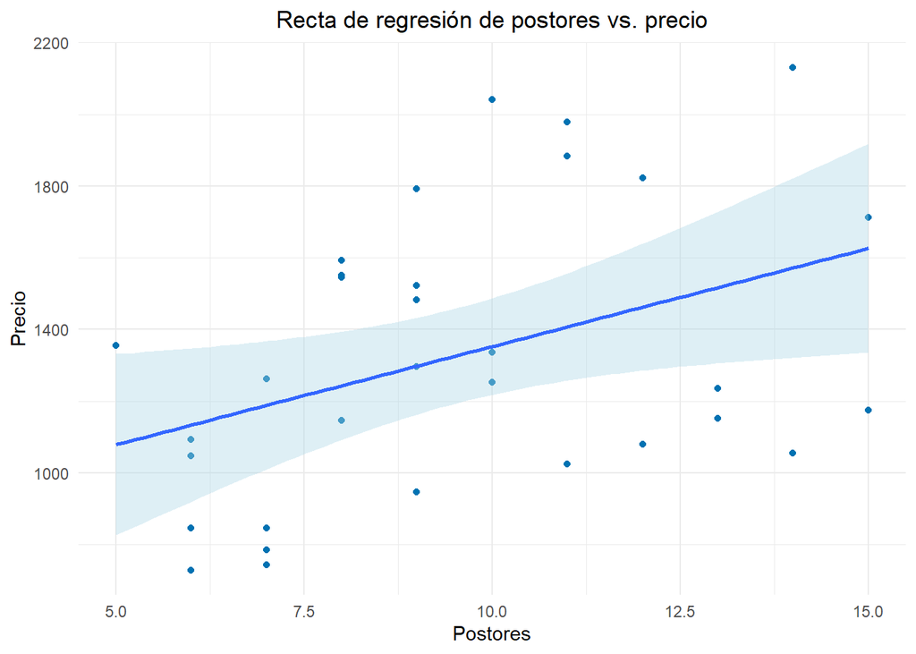

```r
graf.mrls.x2(x1, x2, y, 0.05)
```

### 4. Construcción del modelo de regresión múltiple

Para este caso, se incluirán ambas variables como predictoras, es decir, comparado con los anteriores modelos, aquí se incluirá otro criterio para saber si existe una relación predecible entre las variables, su construcción es similar a la del modelo pasado, únicamente, como se djo al inicio, se incluirán dos variables predictoras que fueron las de los modelos pasados. Para ello se usará el mismo modelo lm que en casos pasados pero haremos la suma de ambas variables.

```r
modmult <- lm(y ~ x1+x2)
anova <- aov(modmult)
summary(anova)
```

```
##             Df  Sum Sq Mean Sq F value   Pr(>F)
## x1           1 2555224 2555224  143.41 9.53e-13 ***
## x2           1 1727838 1727838   96.97 9.34e-11 ***
## Residuals   29  516727   17818
## ---
## Signif. codes:  0 '***' 0.001 '**' 0.01 '*' 0.05 '.' 0.1 ' ' 1
```

Además, al observar el anova podemos ver mucha significancia en las variables predictoras al tener tanto un estadístico alto así como un p valor significativo y que ambas variables predictoras contribuyen al modelo. Igual podemos observar la comparación de media y varianzas y a su vez podemos decir que al menos una $\beta_i$ es distinta de cero.

```r
modmult <- lm(y ~ x1+x2)
anova <- aov(modmult)
summary(modmult)
```

```
##
## Call:
## lm(formula = y ~ x1 + x2)
##
## Residuals:
##     Min      1Q  Median      3Q     Max
## -206.49 -117.34   16.66  102.55  213.50
##
## Coefficients:
##               Estimate Std. Error t value Pr(>|t|)
## (Intercept) -1338.9513   173.8095  -7.704 1.71e-08 ***
## x1             12.7406     0.9047  14.082 1.69e-14 ***
## x2             85.9530     8.7285   9.847 9.34e-11 ***
## ---
## Signif. codes:  0 '***' 0.001 '**' 0.01 '*' 0.05 '.' 0.1 ' ' 1
##
## Residual standard error: 133.5 on 29 degrees of freedom
## Multiple R-squared:  0.8923, Adjusted R-squared:  0.8849
## F-statistic: 120.2 on 2 and 29 DF,  p-value: 9.216e-15
```

Al observar el p valor del estadístico F del modelo, podemos ver que es muy bajo, es decir, es significativo, ya anteriormente habíamos visto el de cada variable por separado e igualmente eran significativos. El error residual de este modelo es mucho más bajo por lo que podemos decir que nuestras predicciones pueden variar en 133.5 a comparación de los datos originales y si se observa con detalle, la confianza de este modelo aumenta significativamente con el número de variables consideradas.

```r
aic(x1, x2, y, 0.05)
```

Test Akaike

| Modelo | AIC |
| --- | --- |
| 1 | 453.8772 |
| 2 | 472.7648 |
| Múltiple | 408.8771 |

Por el criterio de Akaike, parece ser el mejor modelo este de regresión lineal multiple, pues su valor es el más bajo. Esto debido a que toma en cuenta más argumentos para hacer las predicciones.

### 5. Extracción de Información del modelos

Para la extracción de la información del modelo, lo importante a considerar serán nuestras betas, nuestra $S^2$ y nuestro estadístico así como su p valor, para ello, en el primer caso, las betas serán obtenidas con los coeficientes del modelo, especificamente aquellos que se encuentran en la primer fila y en cada una de las columnas.

```r
extr.datos(x1, x2, y, 0.05)
```

Extracción de datos

| Variable | Valor |
| --- | --- |
| β₀ | -1338.95134 |
| β₁ | 12.74057 |
| β₂ | 85.95298 |
| s | 133.48467 |
| s² | 17818.15655 |

### 6. Prueba general del Modelo

La prueba general del modelo se realizará mediante la comparación del valor p, si este es significativo, es decir, es menor que 0.05, el modelo de igual manera será significativo, en caso contrario no existirá evidencia para esta afirmación. Siendo su validación de la siguiente manera y concluyendo que el modelo sí es significativo al rechazar $H_0$

```r
prueb.glob(x1, x2, y, 0.05)
```

Pruebas global para βi

| Variable | Valor |
| --- | --- |
| FC | 120.188161679417 |
| P value f | 0.00000000000000921635859536383 |
| Conclusión | Se rechaza H0, es decir, el modelo es significativo |

### 7. Correlación

```r
corr(x1, x2, y, 0.05)
```

Coeficiente de correlación

| Rho | Conclsuión |
| --- | --- |
| R cuad | Hay una correlación fuerte |
| Valor | 0.892343916353148 |
| R adj | Hay una correlación fuerte |
| Valor | 0.884919358860262 |

R cuadrado (R cuad) es una medida que indica qué porcentaje de la variación en una variable puede explicarse por la otra variable en el modelo de regresión. Un valor de 0.892343916353148 sugiere que aproximadamente el 89.23% de la variación en una variable puede explicarse por la otra variable en este análisis.

R cuadrado ajustado (R adj) es similar a R cuadrado, pero tiene en cuenta el número de predictores en el modelo. Si el valor de R adj es alto, indica que el modelo es adecuado para explicar la variación en la variable dependiente.

En resumen, los valores proporcionados indican que hay una correlación positiva fuerte entre las variables analizadas, y aproximadamente el 89.23% de la variación en una variable puede explicarse por la otra variable en el modelo. Además, tanto R cuadrado como R cuadrado ajustado sugieren que el modelo es adecuado para explicar la relación entre las variables.

### 8. Pruebas Individuales

Para el caso de las pruebas individuales, se va a extraer del modelo cada uno de los p valores de las variables predictoras. Al estar estas en la sección de los coeficientes, bastará con indicar su posición en la matriz para obtenerlas:

Y para sus respectivas pruebas, como en el caso anterior y ya muchos otros modelos, los p valores se compararán con nuestro alpha y podemos observar que en ambos casos se rechaza $H_0$, queriendo decir que ambas betas son significativas para el modelo

```r
prueb.indiv1(x1, x2, y, 0.05)
```

Prueba individual para β₁

| Variable | Valor |
| --- | --- |
| P value β₁ | 0.0000000000000169275643184263 |
| Concusión | Se rechaza H0, es decir, β₁ es significativo para el modelo |

```r
prueb.indiv2(x1, x2, y, 0.05)
```

Prueba individual para β₂

| Variable | Valor |
| --- | --- |
| P value β₂ | 0.0000000000934495315616398 |
| Conclusión | Se rechaza H0, es decir, β₂ es significativo para el modelo |

### 9. Intervalos de confianza para $\beta_i$

Para el calculo de los intervalos de confianza de cada beta, se obtendrá el valor de probabilidad acumulada de una t student de dos colas con $n-1$ grados de libertad y se realizará el calculo para cada beta restandole el producto de la probabilidad acumulada con su error estándar, siendo su calculo de la siguiente manera:

Obteniendo los siguientes resultados, que afirman a un nivel alpha = 0.05 que cada beta se encuentra en ese intervalo.

```r
int.conf.b1(x1, x2, y, 0.05)
```

Int. de confianza β₁

| Límites | Valor |
| --- | --- |
| Inferior | 10.89534 |
| Superior | 14.58580 |

```r
int.conf.b2(x1, x2, y, 0.05)
```

Int. de confianza β₂

| Límites | Valor |
| --- | --- |
| Inferior | 68.15104 |
| Superior | 103.75493 |

### 10. Gráfica del modelo

Al graficar el modelo, podemos observar como puntos rojos cada uno de los datos que tenemos en el modelo y el plano representa nuestro modelo de regresión, la distancia entre cada uno de estos va a ser el error de predicción y al observarlo a detalle podemos ver que todos los errores parecen pequeños.

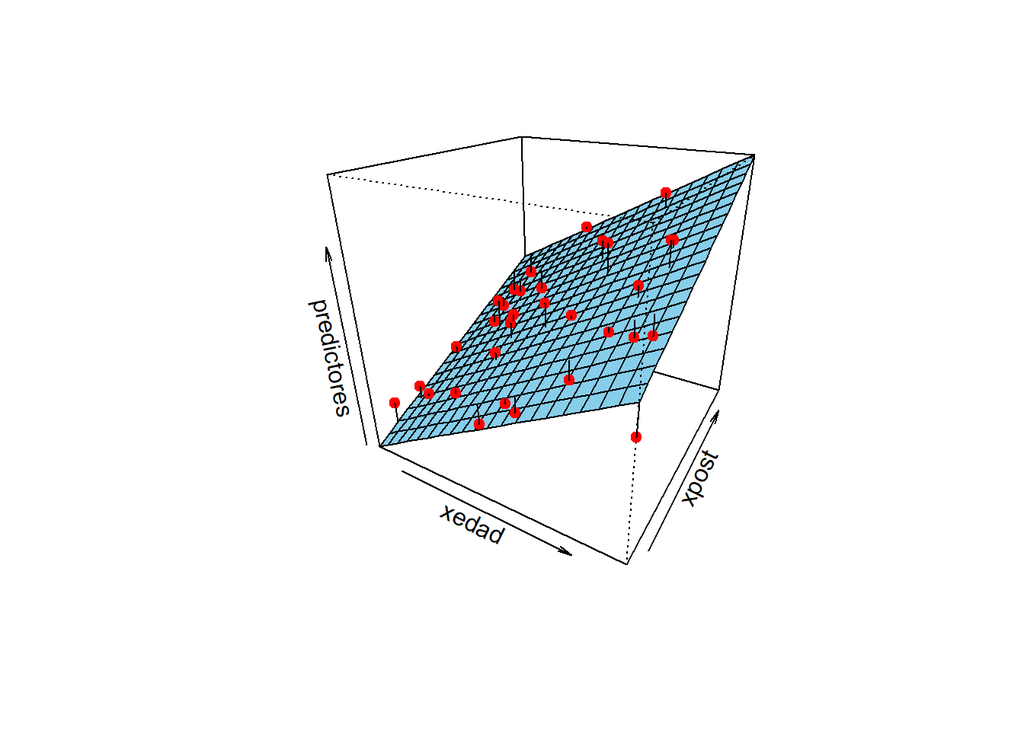

```
## [1] 0.05138413
```

```r
graf.mrlm(x1, x2, y, 0.05)
```

### 11. Análisis de residuales

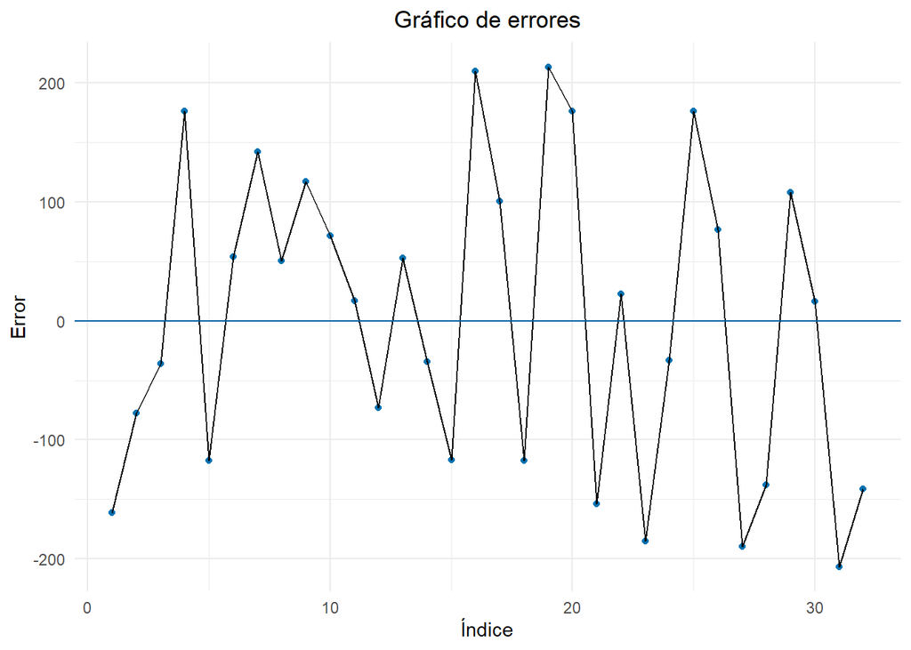

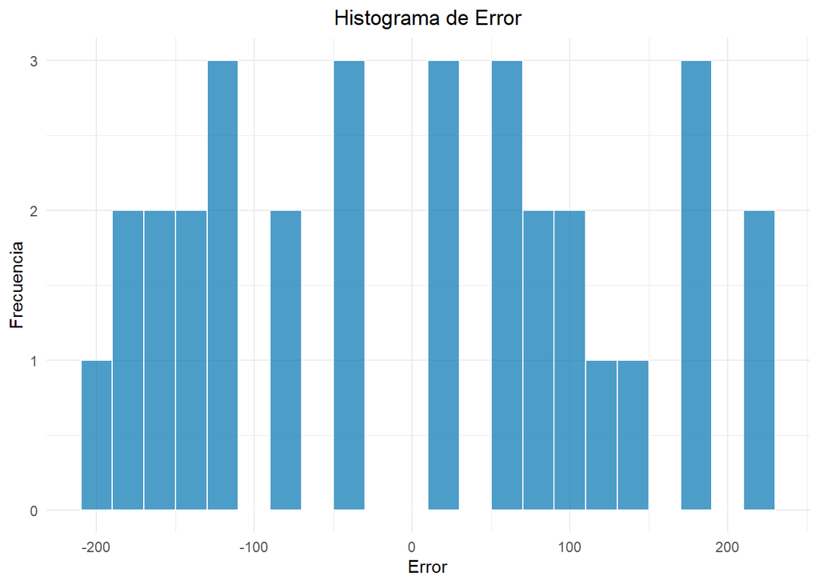

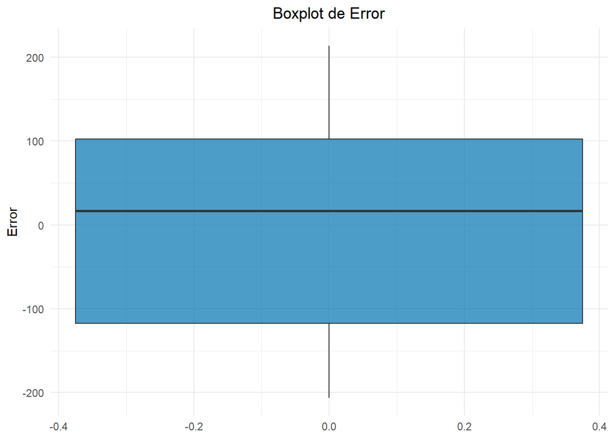

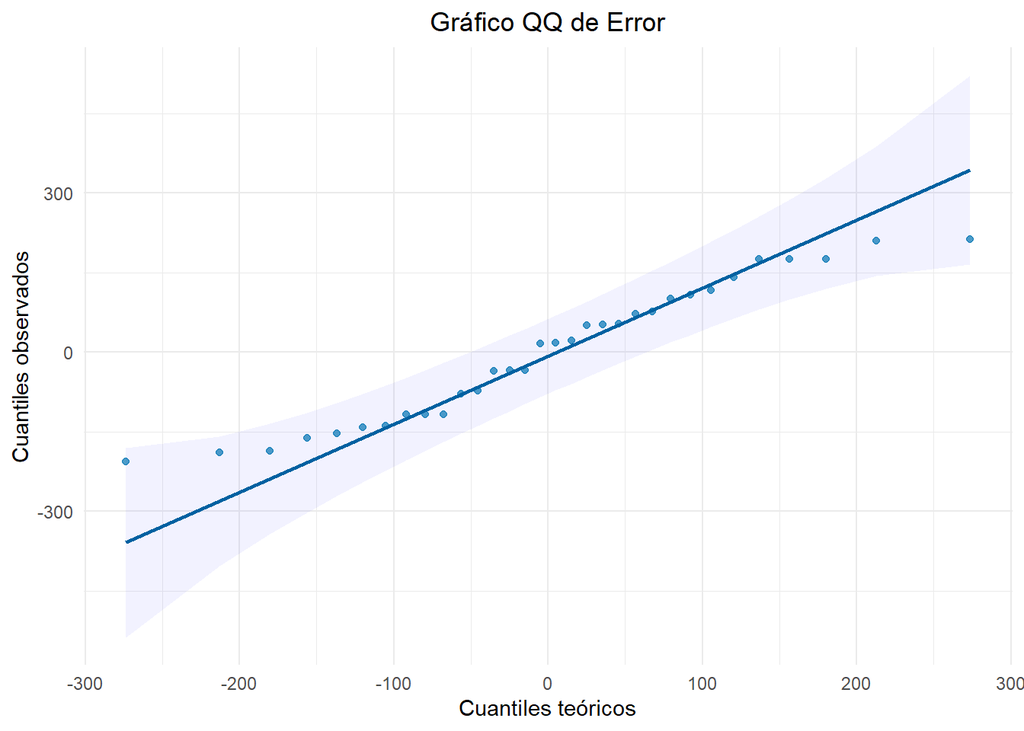

```r
graf.err(x1, x2, y, 0.05)
```

Como el número de datos es mayor que 30, se usará la prueba Lillie y la Anderson para comprobar si los errores se comportan de manera normal con mayor evidencia.

```r
norm.err(x1, x2, y, 0.05)
```

Normalidad H0: Err. norm vs H1: Err. no norm

| Test.Lillie | Valor |
| --- | --- |
| P valor | 0.181286635723582 |
| Conclusión | p valor ≥ α, no rechazamos H0 . |

```r
norm.err2(x1, x2, y, 0.05)
```

Normalidad H0: Err. norm vs H1: Err. no norm

| Test.Anderson | Valor |
| --- | --- |
| P valor | 0.204437140763369 |
| Conclusión | p valor ≥ α, no rechazamos H0 |

### 12. Correlación de los errores

```r
corr.err(x1, x2, y, 0.05)
```

Test Durbin-Watson

| Test | Conclusión |
| --- | --- |
| DW | 1.87200832574999 |
| P valor | 0.355352817154974 |
| Conclusión | No hay una correlación en los residuos |

En el análisis estadístico realizado, se aplicó el Test Durbin-Watson para evaluar la presencia de autocorrelación en los residuos del modelo. El resultado del test arrojó un valor de 1.87200832574999 para el estadístico Durbin-Watson (DW). En este contexto, un valor de DW cercano a 2 sugiere que no hay autocorrelación en los residuos. Además, se calculó el valor P, que fue encontrado como 0.355352817154974. Un valor P mayor que el nivel de significancia (generalmente 0.05) indica que no hay evidencia suficiente para rechazar la hipótesis nula de que no hay autocorrelación en los residuos.

En base a estos resultados, se llega a la conclusión de que no hay una correlación significativa en los residuos del modelo. Esto significa que los errores residuales del modelo analizado no muestran un patrón sistemático en su distribución, lo que refuerza la fiabilidad de las conclusiones obtenidas a partir de este análisis estadístico